# Harmonization Task Using Bach Chorales

```python
import pickle
import numpy as np
import torch
from torch.utils.data import Dataset, DataLoader
import matplotlib.pyplot as plt
from utils2 import *
from collections import Counter
import torch
import torch.nn as nn
import torch.nn.functional as F
import torch.optim as optim
from torch.utils.tensorboard import SummaryWriter
import numpy as np
import matplotlib.pyplot as plt
from pathlib import Path
import time
import random
from network import *
from generate import *

import sys
sys.path.append('.')
```

- https://github.com/czhuang/JSB-Chorales-dataset
- Boulanger-Lewandowski, N., Vincent, P., & Bengio, Y. (2012). Modeling Temporal Dependencies in High-Dimensional Sequences: Application to Polyphonic Music Generation and Transcription. Proceedings of the 29th International Conference on Machine Learning (ICML-12), 1159–1166.
- https://medium.com/@arsenaultk9/artificial-intelligence-music-generation-melody-harmonization-pt1-cb3e92c9a0ca
- Kevin Summerian

```python
def load_original_data():
    """Load the original Bach chorales dataset"""
    try:
        with open('./data/jsb-chorales-16th.pkl', 'rb') as file:
            midi_data = pickle.load(file, encoding="latin1")
        print("✅ Loaded original Bach chorales dataset")
        return midi_data
    except FileNotFoundError:
        print("❌ Original dataset not found at './data/jsb-chorales-16th.pkl'")
        print("Please ensure you have the original Bach chorales dataset file.")
        raise

midi_data = load_original_data()

print(f"Original dataset:")
print(f"  Train: {len(midi_data['train'])} songs")
print(f"  Test: {len(midi_data['test'])} songs")
print(f"  Valid: {len(midi_data['valid'])} songs")
```

```
✅ Loaded original Bach chorales dataset
Original dataset:
  Train: 229 songs
  Test: 77 songs
  Valid: 76 songs
```

## Introduction & Background

### What are Bach Chorales?

Johann Sebastian Bach composed hundreds of four-part chorales (hymns) that are considered masterpieces of Western harmony. Each chorale has four voices:

- **Soprano** (highest voice, melody)
- **Alto** (second highest)
- **Tenor** (second lowest)
- **Bass** (lowest voice, foundation)

### The Machine Learning Goal

We want to train a neural network that can:

1. Take a soprano melody as input
2. Generate harmonious alto, tenor, and bass parts
3. Create music that sounds like Bach's style

### The Dataset

The **JSB Chorales dataset** contains 382 Bach chorales in a digital format, split into:

- **Train**: 229 chorales (for learning)
- **Test**: 77 chorales (for final evaluation)
- **Valid**: 76 chorales (for tuning during training)

## Understanding the Raw Data

### Data Format: Tuple Representation

Each chorale is stored as a sequence of tuples, where each tuple represents one moment in time (0.25 beats):

```
# Example: First few moments of a chorale
[
    (69, 65, 60, 53),  # Time step 0: Soprano=69, Alto=65, Tenor=60, Bass=53
    (69, 65, 60, 53),  # Time step 1: Same notes held
    (71, 67, 62, 55),  # Time step 2: All voices move to new notes
    (72, 69, 64, 57),  # Time step 3: Harmony progression continues
    # ... continues for entire piece
]
```

### MIDI Note Numbers

Each number represents a MIDI note:

- **60** = Middle C
- **69** = A above middle C
- **53** = F below middle C
- Higher numbers = higher pitches

### Key Characteristics

```
Dataset Statistics:
  Total songs: 382
  Average song length: 242.2 time steps
  Note range: 36 to 81
  Total notes: 368860
```

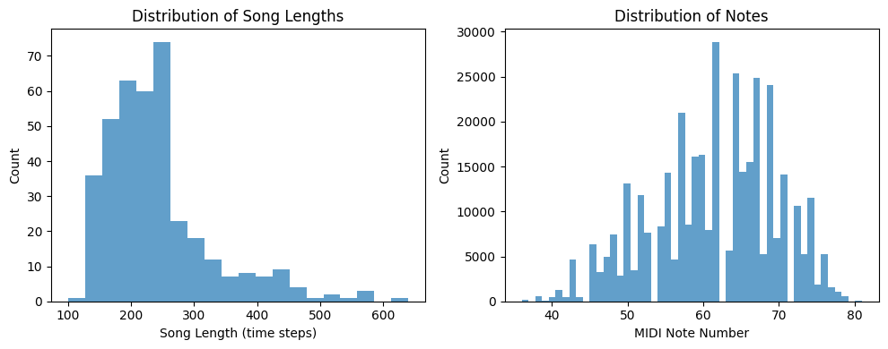

```python
stats = analyze_dataset(midi_data)
```

## Step 1: Data Augmentation Pipeline

### Problem: Limited Training Data

- Only 229 training chorales
- Neural networks need thousands of examples
- Solution: Create variations that preserve musical structure

### Stage 1A: Convert to Structured Format

#### From Tuples to Note Objects

We convert the simple tuple format into rich **NoteInfo** objects:

#### Why This Conversion?

The tuple format only shows "what notes are playing now." This allows us to be able convert these discrete time steps into midi files a lot easier as we capture:

- **When** each note starts
- **How long** each note lasts
- **What pitch** it is
- **Which voice** it belongs to

```python
sample_song = midi_data['train'][0]
sample_note_info = generate_note_info(sample_song)

print(f"\n🎵 Note Info Conversion Test:")
voice_names = ['Soprano', 'Alto', 'Tenor', 'Bass']
for i, voice_notes in enumerate(sample_note_info):
    print(f"  {voice_names[i]}: {len(voice_notes)} notes")
    if voice_notes:
        print(f"    First note: {voice_notes[0]}")
```

```
🎵 Note Info Conversion Test:
  Soprano: 34 notes
    First note: NoteInfo(beat=0.0, pitch=74, length=1.0)
  Alto: 30 notes
    First note: NoteInfo(beat=0.0, pitch=70, length=2.0)
  Tenor: 34 notes
    First note: NoteInfo(beat=0.0, pitch=65, length=1.0)
  Bass: 49 notes
    First note: NoteInfo(beat=0.0, pitch=58, length=1.0)
```

```python
generate_midi_file(sample_note_info, 'test.mid')
```

```
Created track for Soprano with 34 notes
Created track for Alto with 30 notes
Created track for Tenor with 34 notes
Created track for Bass with 49 notes
MIDI file saved: generated_midi/test.mid
```

```
'generated_midi/test.mid'
```

### Stage 1B: Musical Augmentations

#### Scale Transposition (12 variations)

We transpose each chorale to different keys:

```
# Original in C major: (60, 64, 67, 72) - C major chord
# Transpose +2 semitones: (62, 66, 69, 74) - D major chord
# Transpose -3 semitones: (57, 61, 64, 69) - A major chord
```

**Why this works**:

- Harmonic relationships stay the same
- Just shifts everything up/down by same amount
- Creates 12 versions: -5 to +6 semitones

#### Rhythmic Variation (4 variations per scale)

We randomly join short notes together:

```
# Original rhythm:
Note(beat=0, length=0.25)  # Short note
Note(beat=0.25, length=0.25)  # Another short note

# After joining:
Note(beat=0, length=0.5)  # One longer note
```

**Why this works**:

- Preserves harmony but varies rhythm
- Creates natural musical variations
- Bach often used both short and long note values

```python
sample_augmentations = augment_song_data(sample_note_info)
print(f"\n🔄 Augmentation Test:")
print(f"  Original song generated {len(sample_augmentations)} augmented versions")
print(f"  Expected: 12 scales × 4 note variations = 48 versions")
```

```
🔄 Augmentation Test:
  Original song generated 48 augmented versions
  Expected: 12 scales × 4 note variations = 48 versions
```

### Stage 1C: Back to Tuple Format

After augmentation, we convert back to the simple tuple format:

```
NoteInfo objects → Sample every 0.25 beats → Tuple sequences
```

### Augmentation Results

- **Input**: 229 original chorales
- **Output**: ~11,000 augmented chorales (48x increase!)
- **Saved as**: `scales_note_join_augmented.pkl`

```python
sample_tuple_reconstruction = generate_tuple_form(sample_note_info)
print(f"\n🔄 Tuple Reconstruction Test:")
print(f"  Original song length: {len(sample_song)} time steps")
print(f"  Reconstructed length: {len(sample_tuple_reconstruction)} time steps")
print(f"  Original first chord: {sample_song[0]}")
print(f"  Reconstructed first chord: {sample_tuple_reconstruction[0]}")
```

```
🔄 Tuple Reconstruction Test:
  Original song length: 192 time steps
  Reconstructed length: 184 time steps
  Original first chord: (np.int64(74), np.int64(70), np.int64(65), np.int64(58))
  Reconstructed first chord: (74, 70, 65, 58)
```

```python
augmented_midi_data = augment_full_dataset(midi_data)
```

```
🚀 Starting full dataset augmentation...
  Augmenting song 10 of 229 songs
  Augmenting song 20 of 229 songs
  Augmenting song 30 of 229 songs
  Augmenting song 40 of 229 songs
  Augmenting song 50 of 229 songs
  Augmenting song 60 of 229 songs
  Augmenting song 70 of 229 songs
  Augmenting song 80 of 229 songs
  Augmenting song 90 of 229 songs
  Augmenting song 100 of 229 songs
  Augmenting song 110 of 229 songs
  Augmenting song 120 of 229 songs
  Augmenting song 130 of 229 songs
  Augmenting song 140 of 229 songs
  Augmenting song 150 of 229 songs
  Augmenting song 160 of 229 songs
  Augmenting song 170 of 229 songs
  Augmenting song 180 of 229 songs
  Augmenting song 190 of 229 songs
  Augmenting song 200 of 229 songs
  Augmenting song 210 of 229 songs
  Augmenting song 220 of 229 songs

✅ Augmentation completed!
  Original training songs: 229
  Augmented training songs: 10992
  Augmentation factor: 48.0x
```

```python
output_file = save_augmented_dataset(augmented_midi_data)


verify_saved_data(output_file)

print("\n" + "="*70)
print("🎉 COMPLETE AUGMENTATION PIPELINE FINISHED!")
print("="*70)
print(f"\n📁 Generated file: ./data/scales_note_join_augmented.pkl")
```

```
💾 Augmented dataset saved to: ./data/scales_note_join_augmented.pkl
  File size: 30.1 MB

🔍 Verifying saved data...
✅ Successfully loaded augmented dataset
  Train: 10992 songs
  Test: 77 songs
  Valid: 76 songs
  Sample song length: 184 time steps
  Sample first chord: (69, 65, 60, 53)

======================================================================
🎉 COMPLETE AUGMENTATION PIPELINE FINISHED!
======================================================================

📁 Generated file: ./data/scales_note_join_augmented.pkl
```

## Step 2: Training Data Preparation

```python
def load_augmented_data():
    """Load the previously augmented dataset"""

    path = './data/scales_note_join_augmented.pkl'  # Original pipeline output

    try:
        with open(path, 'rb') as file:
            midi_data = pickle.load(file, encoding="latin1")
            print(f"Loaded {path}")
    except FileNotFoundError:
        print(f"File not found: {path}")


    print(f"Dataset splits:")
    print(f"  Train: {len(midi_data['train'])} songs")
    print(f"  Test: {len(midi_data['test'])} songs")
    print(f"  Valid: {len(midi_data['valid'])} songs")

    return midi_data

midi_data = load_augmented_data()

sample_song = midi_data['train'][0]
print(f"\nSample song structure:")
print(f"  Length: {len(sample_song)} time steps")
print(f"  First chord: {sample_song[0]}")
print(f"  Chord sizes: {[len(chord) for chord in sample_song[:5]]}")
```

```
Loaded ./data/scales_note_join_augmented.pkl
Dataset splits:
  Train: 10992 songs
  Test: 77 songs
  Valid: 76 songs

Sample song structure:
  Length: 184 time steps
  First chord: (69, 65, 60, 53)
  Chord sizes: [4, 4, 4, 4, 4]
```

### Stage 2A: Voice Assignment Challenge

#### The Problem

Not all chords have exactly 4 notes. Sometimes we see:

- `(69, 65, 60)` - Only 3 notes
- `(69, 65)` - Only 2 notes

But our neural network expects exactly 4 voices (SATB). How do we assign notes to voices?

#### The Solution: Smart Voice Tracking

We use a **VoiceTracker** for each voice that:

1. **Prefers consistency**: If soprano was playing note 69, try to keep it on 69
2. **Respects ranges**: Soprano gets high notes, bass gets low notes
3. **Uses musical logic**: When in doubt, soprano takes highest available note

```
# Example assignment logic:
chord = (65, 69, 72)  # 3 notes available
# Soprano (highest): gets 72
# Alto (middle): gets 69
# Tenor (lower): gets 65
# Bass: gets silence (no suitable note)
```

### Stage 2B: One-Hot Encoding

#### Why One-Hot Encoding?

Neural networks work with numbers, not musical concepts. We convert each note to a vector:

```
# Note 65 in Alto voice (range 51-82, total 33 positions):
# Position 0: Silence
# Position 1: Note 51
# Position 2: Note 52
# ...
# Position 15: Note 65 ← This gets value 1.0
# Position 16: Note 66
# ...
# Position 32: Note 82
```

#### The Encoding Process

For each voice at each time step:

1. Determine which note is playing (or silence)
2. Create a vector of zeros
3. Set exactly one position to 1.0

**Result**: Each time step becomes a vector of n + 1 numbers (n possible notes + silence) depending on the SATB line. For example, for alto, there will be 33 (32 + 1) positions while bass is 40 (39 + 1) total.

```python
print("Voice ranges:")
for voice, range_obj in VOICE_RANGES.items():
    print(f"  {voice}: {range_obj.min_note}-{range_obj.max_note} ({range_obj.range_and_silence_length()} total)")
```

```
Voice ranges:
  soprano: 56-87 (33 total)
  alto: 51-82 (33 total)
  tenor: 46-77 (33 total)
  bass: 31-69 (40 total)
```

```python
train_one_hot = process_songs_to_one_hot(midi_data['train'])
test_one_hot = process_songs_to_one_hot(midi_data['test'])
valid_one_hot = process_songs_to_one_hot(midi_data['valid'])
```

[output not shown]

[output cut: 60 more lines]

```
  Processing song 9901/10992
  Processing song 10001/10992
  Processing song 10101/10992
  Processing song 10201/10992
  Processing song 10301/10992
  Processing song 10401/10992
  Processing song 10501/10992
  Processing song 10601/10992
  Processing song 10701/10992
  Processing song 10801/10992
  Processing song 10901/10992
Converting 77 songs to one-hot encoding...
  Processing song 1/77
Converting 76 songs to one-hot encoding...
  Processing song 1/76
```

### Stage 2C: Sequence Splitting

#### Sequence Length: 64 Time Steps

- **Musical Meaning**: 64 × 0.25 beats = 16 beats = 4 measures
- **Perfect Size**: Long enough for musical phrases, short enough for memory
- **Standard Practice**: Common length in music AI research

```
# Long song (200 time steps):
Song: [measures 1-2-3-4-5-6-7-8-9-10-11-12-13...]

# Split into sequences:
Sequence 1: [measures 1-2-3-4]     # Time steps 0-63
Sequence 2: [measures 5-6-7-8]     # Time steps 64-127
Sequence 3: [measures 9-10-11-12]  # Time steps 128-191
```

```python
train_sequences = create_sequence_dataset(train_one_hot)
test_sequences = create_sequence_dataset(test_one_hot)
valid_sequences = create_sequence_dataset(valid_one_hot)

print(f"Train sequences: {len(train_sequences['soprano'])}")
print(f"Test sequences: {len(test_sequences['soprano'])}")
print(f"Valid sequences: {len(valid_sequences['soprano'])}")
```

```
Splitting soprano into sequences...
  Created 32832 sequences of length 64
Splitting alto into sequences...
  Created 32832 sequences of length 64
Splitting tenor into sequences...
  Created 32832 sequences of length 64
Splitting bass into sequences...
  Created 32832 sequences of length 64
Splitting soprano into sequences...
  Created 271 sequences of length 64
Splitting alto into sequences...
  Created 271 sequences of length 64
Splitting tenor into sequences...
  Created 271 sequences of length 64
Splitting bass into sequences...
  Created 271 sequences of length 64
Splitting soprano into sequences...
  Created 260 sequences of length 64
Splitting alto into sequences...
  Created 260 sequences of length 64
Splitting tenor into sequences...
  Created 260 sequences of length 64
Splitting bass into sequences...
  Created 260 sequences of length 64
Train sequences: 32832
Test sequences: 271
Valid sequences: 260
```

### Stage 2D: Dataset Creation

#### Input vs. Output Format

- **Input (X)**: Soprano melody as one-hot vectors `[batch_size, 64, 33]`
- **Output (Y)**: Alto/Tenor/Bass as class indices `[batch_size, 64]`

#### Why Different Formats?

- **Input**: One-hot gives network rich information about melody
- **Output**: Class indices work better with loss functions for classification

### Stage 2E: DataLoader Creation

#### Batching for Training

Instead of processing one sequence at a time, we group them:

```
# Batch of 4 sequences:
Batch = [
    Sequence_1,  # 64 time steps of 4-part harmony
    Sequence_2,  # 64 time steps of 4-part harmony
    Sequence_3,  # 64 time steps of 4-part harmony
    Sequence_4   # 64 time steps of 4-part harmony
]
```

**Final Tensor Shapes**:

- **Soprano Input**: `[4, 64, 33]` - 4 sequences, 64 time steps, 33 possible notes
- **Alto Target**: `[4, 64]` - 4 sequences, 64 time steps, 1 note index per step
- **Tenor Target**: `[4, 64]` - Same format
- **Bass Target**: `[4, 64]` - Same format

```python
train_dataset = ChoralesDataset(train_sequences)
test_dataset = ChoralesDataset(test_sequences)
valid_dataset = ChoralesDataset(valid_sequences)
```

```
Dataset created with 32832 sequences
  Input shape: torch.Size([32832, 64, 33])
  Target shapes: torch.Size([32832, 64]), torch.Size([32832, 64]), torch.Size([32832, 64])
Dataset created with 271 sequences
  Input shape: torch.Size([271, 64, 33])
  Target shapes: torch.Size([271, 64]), torch.Size([271, 64]), torch.Size([271, 64])
Dataset created with 260 sequences
  Input shape: torch.Size([260, 64, 33])
  Target shapes: torch.Size([260, 64]), torch.Size([260, 64]), torch.Size([260, 64])
```

```python
train_loader, test_loader, valid_loader = create_data_loaders(
    train_dataset, test_dataset, valid_dataset
)
```

```
DataLoaders created:
  Train: 8208 batches of size 4
  Test: 67 batches of size 4
  Valid: 65 batches of size 4
```

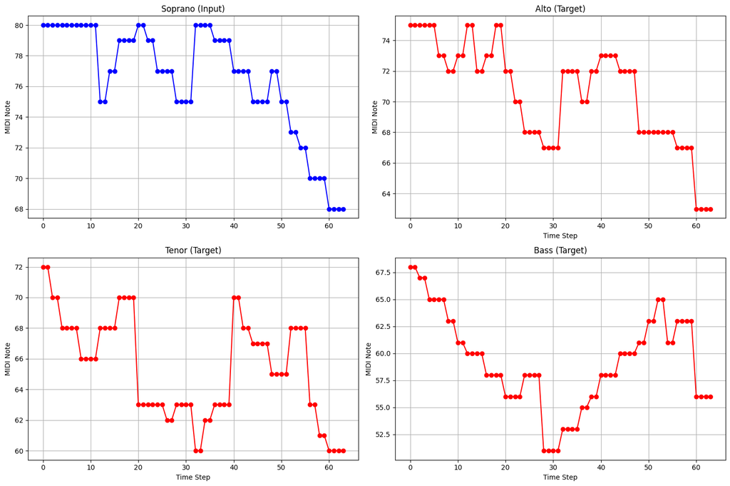

```
Sample sequence statistics:
  Soprano range: 68 - 80
  Unique notes: 8
```

```python
visualize_training_data(train_loader) # example of a input (blue being input and red being target sequence)
```

```python
def save_processed_data():
    """Save the processed datasets for later use"""

    processed_data = {
        'train_dataset': train_dataset,
        'test_dataset': test_dataset,
        'valid_dataset': valid_dataset,
        'voice_ranges': VOICE_RANGES,
        'config': {
            'sequence_length': SEQUENCE_LENGTH,
            'batch_size': BATCH_SIZE,
            'silence_index': SILENCE_INDEX
        }
    }

    torch.save(processed_data, './data/processed_training_data.pt')
    print("Processed data saved to './data/processed_training_data.pt'")

save_processed_data()
```

```
Processed data saved to './data/processed_training_data.pt'
```

## Network Architecture

### **Network Type**: Feedforward (Dense/Linear layers only)

### **Task**: Multi-output classification (3 separate voice predictions)

### **Input**: Complete soprano melody sequence

### **Output**: Complete harmony sequences for 3 voices

## Input/Output Specifications

### **Input Dimensions**

```
# Soprano melody input
Input Shape: [batch_size, sequence_length, encoding_size]
           = [4, 64, 33]

# After flattening for network:
Flattened:  [batch_size, sequence_length × encoding_size]
          = [4, 2112]

# Where:
# - batch_size = 4 (training batch size)
# - sequence_length = 64 (time steps)
# - encoding_size = 33 (32 MIDI notes + 1 silence)
```

### **Output Dimensions**

```
# Three separate voice outputs
Alto Output:  [batch_size, encoding_size, sequence_length] = [4, 33, 64]
Tenor Output: [batch_size, encoding_size, sequence_length] = [4, 33, 64]
Bass Output:  [batch_size, encoding_size, sequence_length] = [4, 40, 64]

# Note: Bass has larger encoding (40) due to wider MIDI range
```

## Layer-by-Layer Architecture

```
Input: Soprano Melody
       [4, 64, 33] → Flatten → [4, 2112]
              ↓
┌─────────────────────────────────────────┐
│          INPUT LAYER                    │
│  Linear(2112 → 200)                     │
│  Learnable Parameters: 422,600          │
└─────────────────────────────────────────┘
              ↓
┌─────────────────────────────────────────┐
│         HIDDEN LAYER 1                  │
│  Linear(200 → 200)                      │
│  ReLU Activation                        │
│  Dropout(p=0.5)                         │
│  Learnable Parameters: 40,200           │
└─────────────────────────────────────────┘
              ↓
┌─────────────────────────────────────────┐
│         HIDDEN LAYER 2                  │
│  Linear(200 → 200)                      │
│  ReLU Activation                        │
│  Dropout(p=0.5)                         │
│  Learnable Parameters: 40,200           │
└─────────────────────────────────────────┘
              ↓
         ┌─────────┐
         │ SPLIT   │
         └─────────┘
    ┌────────┴────────┬────────┐
    ↓                 ↓        ↓
┌─────────┐    ┌──────────┐   ┌─────────┐
│  ALTO   │    │  TENOR   │   │  BASS   │
│ BRANCH  │    │  BRANCH  │   │ BRANCH  │
└─────────┘    └──────────┘   └─────────┘
```

## Voice-Specific Output Branches

### **Alto Branch**

```
# Alto harmonizer
Linear(200 → 2112)              # 200 → 64×33
ReLU Activation
Reshape(2112 → [33, 64])        # [encoding_size, sequence_length]
Log Softmax(dim=1)              # Probability distribution over notes

# Output: [batch_size, 33, 64] log probabilities
```

### **Tenor Branch**

```
# Tenor harmonizer
Linear(200 → 2112)              # 200 → 64×33
ReLU Activation
Reshape(2112 → [33, 64])        # [encoding_size, sequence_length]
Log Softmax(dim=1)              # Probability distribution over notes

# Output: [batch_size, 33, 64] log probabilities
```

### **Bass Branch**

```
# Bass harmonizer
Linear(200 → 2560)              # 200 → 64×40 (wider range!)
ReLU Activation
Reshape(2560 → [40, 64])        # [encoding_size, sequence_length]
Log Softmax(dim=1)              # Probability distribution over notes

# Output: [batch_size, 40, 64] log probabilities
```

## Key Design Decisions

### **1. Feedforward Architecture**

- **Why**: Simpler than RNNs, focuses on harmonic relationships
- **Trade-off**: Less temporal modeling, but faster training
- **Justification**: Bach chorales have strong harmonic patterns that feedforward can capture

### **2. Sequence-to-Sequence Processing**

- **Input**: Entire 64-note soprano sequence at once
- **Output**: Entire 64-note harmony sequences for 3 voices
- **Benefit**: Network sees full musical context, can plan ahead

### **3. Separate Output Branches**

- **Why**: Each voice has different characteristics and ranges
- **Implementation**: Dedicated linear layer for each voice
- **Advantage**: Voice-specific learning, different output dimensions